# Timing of copy neutral loss-of-heterozygosity events in endometrial glands

Markdown file to present the methods to examine timing of copy neutral loss-of-heterozygosity events in endometrial glands. Before you start the following analyses, please convert the corresponding excel source data files to tab-delimited text files. The source data files are provided in our paper (Yamaguchi et al. Nat Commun in press).

## Load libraries

```r
library(dplyr)
library(ggplot2)
library(tidyr)
```

## Timing of copy neutral loss-of-heterozygosity in endometrial glands of subject 36

## Load data

```r
mafData <- read.table("source_data_18.txt", header=T, sep="\t", as.is=T)
head(mafData)
```

```
##   mut_group       sample  chr       pos ref alt    purity num_ref_read
## 1    public S36-C-13-WGS chr3 116577713   G   A 0.7804767            2
## 2    public S36-C-15-WGS chr3 116577713   G   A 0.7368713            1
## 3    public S36-D-18-WGS chr3 116577713   G   A 0.8095689            3
## 4    public S36-D-20-WGS chr3 116577713   G   A 0.7214227            5
## 5    public  S36-D-2-WGS chr3 116577713   G   A 0.7487556            4
## 6    public  S36-D-4-WGS chr3 116577713   G   A 0.8492668            1
##   num_alt_read depth mutant_allele_frequency
## 1           21    23               0.9130435
## 2           13    14               0.9285714
## 3           13    16               0.8125000
## 4           22    27               0.8148148
## 5           21    25               0.8400000
## 6           14    15               0.9333333
```

## Visualize mutant allele frequencies of public somatic mutations located in regions affected by copy neutral loss-of-heterozygosity

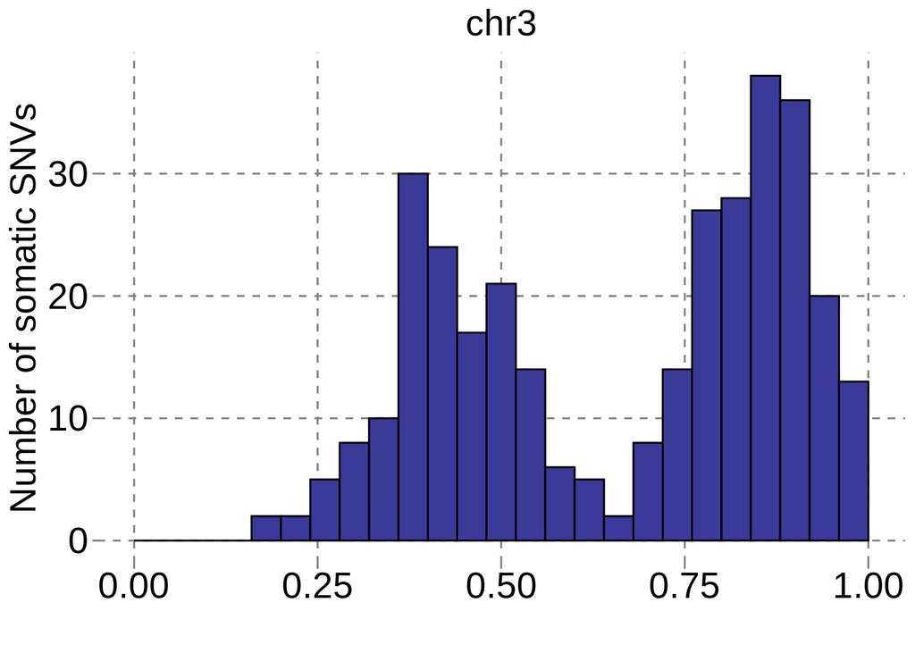

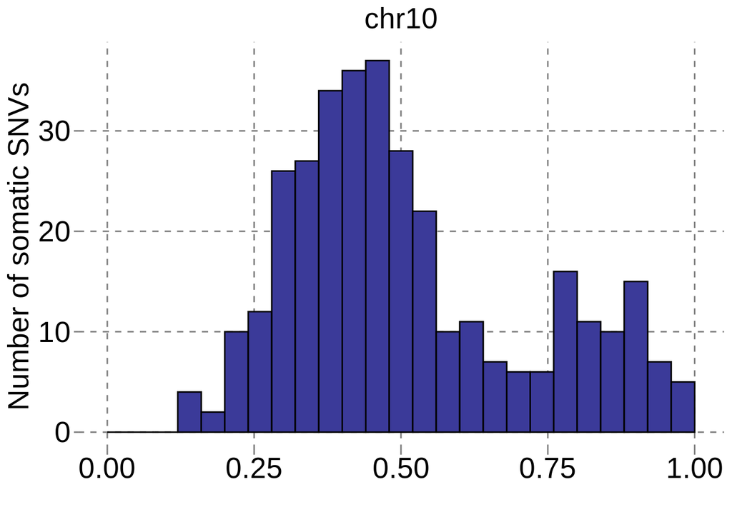

```r
chr_list = c("chr3", "chr10")

for (i in 1:length(chr_list)) {
  mafData_2 <- mafData[mafData$chr == chr_list[i], ]

  p_hist <- ggplot(mafData_2, aes(x=mutant_allele_frequency))
  p_hist <- p_hist + geom_histogram(breaks=seq(0, 1, by=0.04), colour="black", fill="#3b3a99")
  p_hist <- p_hist + ggtitle(chr_list[i])
  p_hist <- p_hist + xlab("")
  p_hist <- p_hist + ylab("Number of somatic SNVs")
  p_hist <- p_hist + theme(
    axis.text.x=element_text(size=20, colour="black"),
    axis.text.y=element_text(size=20, colour="black"),
    axis.title=element_text(size=20),
    plot.title=element_text(size=20, hjust=0.5),
    panel.grid.major=element_line(colour="gray50", linetype="dashed"),
    panel.border=element_blank(),
    panel.background=element_blank(),
    axis.ticks=element_line(colour="gray50"))

  print(p_hist)
}
```

## Estimation of binomial probabilities that public mutations occurred before or after copy neutral loss-of-heterozygosity event based on single gland

```r
mafData$binom_pre <- mapply(
  function(a, b, c) {
    return(dbinom(a, b, prob=c))},
  mafData$num_alt_read, mafData$depth, mafData$purity)

mafData$binom_post <- mapply(
  function(a, b, c) {
    return(dbinom(a, b, prob=c))},
  mafData$num_alt_read, mafData$depth, mafData$purity/2)

write.table(mafData, "source_data_18_binom_prob.txt", quote=F, col.names=T, row.names=F, append=F, sep="\t")
# The result is incorporated in the file "source_data_18_binom_prob.txt", which is used as the input file for the subsequent analyses.
```

## Estimation of joint probabilities that public mutations occurred before or after copy neutral loss-of-heterozygosity event based on multiple glands

```r
# Joint probabilities that public mutations occurred before or after copy neutral loss-of-heterozygosity event based on multiple glands can be estimated by using a Perl script "estimate_joint_prob.pl", which also performs a simulation study to estimate the variances of the joint probabilities.
# Please conduct the following command:
# perl estimate_joint_prob.pl \
#  --input source_data_18_binom_prob.txt \
#  --iter 10000 \
#  --out1 source_data_18_joint_prob.txt \
#  --out2 source_data_18_simulation_result.txt

# If you want to increase or decrease the number of iterations of simulation, please change the option "--iter".
# The Perl script uses random number generator; therefore, the resulting output file "source_data_18_simulation_result.txt" may slightly differ by individual runs.
# We provide the output file "source_data_18_simulation_result_yamaguchi.txt", which was generated in our study (Yamaguchi et al. Nat Commun in press), to illustrate the estimation of timing of copy neutral loss-of-heterozygosity events and their confidence intervals.
```

## Estimation of timing of copy neutral loss-of-heterozygosity events and their confidence intervals

## Load data

```r
simData <- read.table("source_data_18_simulation_result_yamaguchi.txt", header=T, sep="\t", as.is=T)
head(simData)
```

```
##   iteration num_pre_chr3 num_pos_chr3 prop_pre_chr3 var_prop_pre_chr3
## 1         1           62           24     0.7209302       0.002339417
## 2         2           62           24     0.7209302       0.002339417
## 3         3           62           24     0.7209302       0.002339417
## 4         4           62           24     0.7209302       0.002339417
## 5         5           62           24     0.7209302       0.002339417
## 6         6           62           24     0.7209302       0.002339417
##   num_pre_chr10 num_pos_chr10 prop_pre_chr10 var_prop_pre_chr10
## 1            24            45      0.3478261        0.003287581
## 2            24            45      0.3478261        0.003287581
## 3            24            45      0.3478261        0.003287581
## 4            24            45      0.3478261        0.003287581
## 5            24            45      0.3478261        0.003287581
## 6            24            45      0.3478261        0.003287581
```

## Estimation of timing of copy neutral loss-of-heterozygosity events and their confidence intervals in endometrial glands of subject 36

```r
sample_age <- 50 + 5/12
prop_public <- 0.9760442
var_prop_public <- 8.412926e-06

simData$time_chr3 <- sample_age * prop_public * simData$prop_pre_chr3
simData$var_chr3 <- var_prop_public * simData$var_prop_pre_chr3 + prop_public^2 * simData$var_prop_pre_chr3 + simData$prop_pre_chr3^2 * var_prop_public
simData$time_chr3_lower95 <- sample_age * (prop_public * simData$prop_pre_chr3 - 1.96 * sqrt(simData$var_chr3))
simData$time_chr3_upper95 <- sample_age * (prop_public * simData$prop_pre_chr3 + 1.96 * sqrt(simData$var_chr3))

simData$time_chr10 <- sample_age * prop_public * simData$prop_pre_chr10
simData$var_chr10 <- var_prop_public * simData$var_prop_pre_chr10 + prop_public^2 * simData$var_prop_pre_chr10 + simData$prop_pre_chr10^2 * var_prop_public
simData$time_chr10_lower95 <- sample_age * (prop_public * simData$prop_pre_chr10 - 1.96 * sqrt(simData$var_chr10))
simData$time_chr10_upper95 <- sample_age * (prop_public * simData$prop_pre_chr10 + 1.96 * sqrt(simData$var_chr10))

res <- data.frame(
  Chromosome=c("chr3", "chr10"),
  Age=c(mean(simData$time_chr3), mean(simData$time_chr10)),
  Lower_95=c(mean(simData$time_chr3_lower95), mean(simData$time_chr10_lower95)),
  Upper_95=c(mean(simData$time_chr3_upper95), mean(simData$time_chr10_upper95)))

# Timing of copy neutral loss-of-heterozygosity at chromosomes 3 and 10
res
```

```
##   Chromosome      Age Lower_95 Upper_95
## 1       chr3 35.47618 30.80657 40.14579
## 2      chr10 17.27860 11.74192 22.81528
```

## Visualize timing of copy neutral loss-of-heterozygosity events in endometrial glands of subject 36

## Load data

```r
cnlohData <- read.table("source_data_19.txt", header=T, sep="\t", as.is=T)
cnlohData
```

```
##   chromosome mutation_group mutation_burden prop_mutation_burden
## 1       chr3  Before CN-LOH         62.0000            0.7209302
## 2       chr3   After CN-LOH         24.0000            0.2790698
## 3      chr10  Before CN-LOH         24.2798            0.3511275
## 4      chr10   After CN-LOH         44.8601            0.6488725
```

## Visualize timing of copy neutral loss-of-heterozygosity events in endometrial glands of subject 36

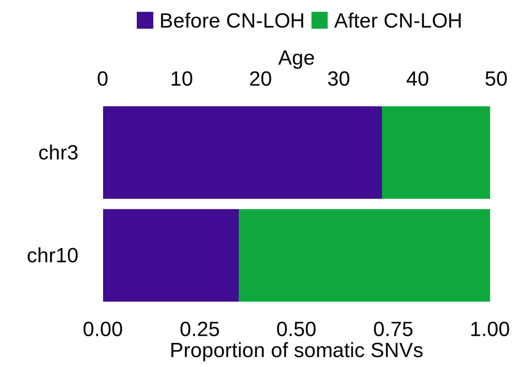

```r
cnlohData$mutation_group2 <- factor(cnlohData$mutation_group, levels=c("After CN-LOH", "Before CN-LOH"))
cnlohData$chromosome2 <- factor(cnlohData$chromosome, levels=c("chr10", "chr3"))
my_colors <- c("#400d93", "#0fa83f")

p_t <- ggplot(data=cnlohData, aes(x=chromosome2, y=prop_mutation_burden, fill=mutation_group2))
p_t <- p_t + geom_bar(stat="identity", position="fill")
p_t <- p_t + scale_y_continuous(sec.axis=sec_axis(~ . * sample_age * prop_public, name="Age"))
p_t <- p_t + scale_fill_manual(values=my_colors, name="",
  breaks=c("Before CN-LOH", "After CN-LOH"))
p_t <- p_t + coord_flip()
p_t <- p_t + xlab("")
p_t <- p_t + ylab("Proportion of somatic SNVs")
p_t <- p_t + theme(
  axis.ticks=element_blank(),
  axis.text.x=element_text(size=20, colour="black"),
  axis.text.y=element_text(size=20, colour="black"),
  axis.title=element_text(size=20),
  legend.text=element_text(size=20),
  panel.grid.major=element_blank(),
  panel.border=element_blank(),
  panel.background=element_blank(),
  legend.position="top")

plot(p_t)
```